# Homework-2

Naren Mohan, Srujana Gaddam, Simran Bhatia

9/27/2021

```r
library("dplyr")
library("magrittr")
library("ggplot2")
library("lubridate")
library("stringr")
library("reshape2")
```

### Problem 1 (20 points)

```r
print("Current Range of x: 1 to 1000")
```

```
## [1] "Current Range of x: 1 to 1000"
```

```r
x <- 1:1000

tic <- Sys.time()
for (i in 1:length(x)) {
  x[i] <- x[i] * 2
}
toc <- Sys.time()

time_for_1 <- (toc - tic) * 1000
cat("Time taken by the \"for loop\":", time_for_1, "ms\n")
```

```
## Time taken by the "for loop": 2.476931 ms
```

```r
x <- 1:1000

tic <- Sys.time()
x <- x * 2
toc <- Sys.time()

time_vec_1 <- (toc - tic) * 1000
cat("Time taken by the vector operation:", time_vec_1, "ms\n")
```

```
## Time taken by the vector operation: 0.5300045 ms
```

```r
print("Current Range of x: 1 to 100000")
```

```
## [1] "Current Range of x: 1 to 100000"
```

```r
x <- 1:100000

tic <- Sys.time()
for (i in 1:length(x)) {
  x[i] <- x[i] * 2
}
toc <- Sys.time()

time_for_2 <- (toc - tic) * 1000
cat("Time taken by the \"for loop\":", time_for_2, "ms\n")
```

```
## Time taken by the "for loop": 4.680157 ms
```

```r
x <- 1:100000

tic <- Sys.time()
x <- x * 2
toc <- Sys.time()

time_vec_2 <- (toc - tic) * 1000
cat("Time taken by the vector operation:", time_vec_2, "ms\n")
```

```
## Time taken by the vector operation: 1.004934 ms
```

```r
print("Current Range of x: 1 to 1000000")
```

```
## [1] "Current Range of x: 1 to 1000000"
```

```r
x <- 1:1000000

tic <- Sys.time()
for (i in 1:length(x)) {
  x[i] <- x[i] * 2
}
toc <- Sys.time()

time_for_3 <- (toc - tic) * 1000
cat("Time taken by the \"for loop\":", time_for_3, "ms\n")
```

```
## Time taken by the "for loop": 32.80878 ms
```

```r
x <- 1:1000000

tic <- Sys.time()
x <- x * 2
toc <- Sys.time()

time_vec_3 <- (toc - tic) * 1000
cat("Time taken by the vector operation:", time_vec_3, "ms\n")
```

```
## Time taken by the vector operation: 2.434015 ms
```

```r
print("Current Range of x: 1 to 10000000")
```

```
## [1] "Current Range of x: 1 to 10000000"
```

```r
x <- 1:10000000

tic <- Sys.time()
for (i in 1:length(x)) {
  x[i] <- x[i] * 2
}
toc <- Sys.time()

time_for_4 <- (toc - tic) * 1000
cat("Time taken by the \"for loop\":", time_for_4, "ms\n")
```

```
## Time taken by the "for loop": 362.0222 ms
```

```r
x <- 1:10000000

tic <- Sys.time()
x <- x * 2
toc <- Sys.time()

time_vec_4 <- (toc - tic) * 1000
cat("Time taken by the vector operation:", time_vec_4, "ms\n")
```

```
## Time taken by the vector operation: 27.93694 ms
```

#### Tabulating the results

```r
df_time <- data.frame("range_of_x" = c("1 to 1,000", "1 to 100,000", "1 to 1,000,000",
                                     "1 to 10,000,000"),
                      "time_taken_for_loop" = c(time_for_1, time_for_2, time_for_3, time_for_4),
                      "time_taken_vector" = c(time_vec_1, time_vec_2, time_vec_3, time_vec_4))

df_time$time_taken_for_loop <- as.numeric(df_time$time_taken_for_loop)
df_time$time_taken_vector <- as.numeric(df_time$time_taken_vector)

df_time_melt <- melt(df_time[, c('range_of_x', 'time_taken_for_loop', 'time_taken_vector')], id.vars=1)
df_time_melt$range_of_x <- factor(df_time_melt$range_of_x, levels = c("1 to 1,000", "1 to 100,000",
                                                         "1 to 1,000,000", "1 to 10,000,000"))

print(df_time)
```

```
##        range_of_x time_taken_for_loop time_taken_vector
## 1      1 to 1,000            2.476931         0.5300045
## 2    1 to 100,000            4.680157         1.0049343
## 3  1 to 1,000,000           32.808781         2.4340153
## 4 1 to 10,000,000          362.022161        27.9369354
```

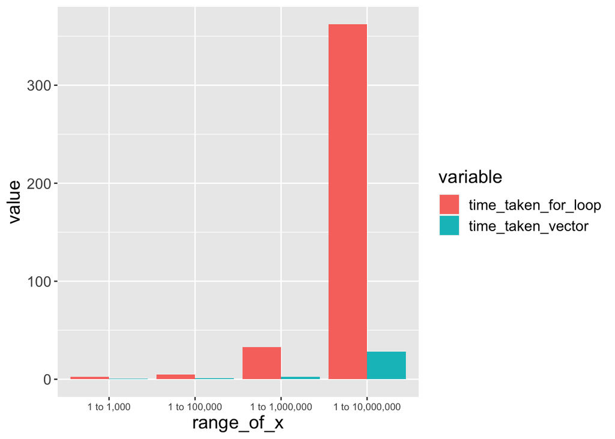

```r
print(ggplot(df_time_melt, aes(x=range_of_x, y=value))+
  geom_bar(aes(fill = variable), stat = "identity", position = "dodge") +
  theme(text = element_text(size=15), axis.text.x = element_text(size = 8)))
```

#### Write your observations on the effect of vector length on computing time using “for loop” and vector operation

From the above bar plot, it is clear that vector operations take significantly lesser time than the for loop operations. As the length of the vector increases, the difference between the time taken to execute for loop and vector operations increases by huge margins. Hence, it is highly recommended to use vector operations wherever possible in place of for loops. This is due to SIMD (Single Instruction, Multiple Data) processing which enables the processor to execute single type of function (here multiplying by 2) on many elements parallelly as opposed to for loop’s sequential loop execution.

### Problem 2 (10 Points)

#### Write a custom function that accepts a dataframe from the user and returns a dataframe sample with a random number of records. The fraction of records must be given by the user in the form of an argument. If the user enters a non-numeric argument, notify using an error message that they have to enter a numeric value.

```r
rand_sample_func <- function(df, frac) {
  if (!is.integer(frac)) {
    print("The input argument \"frac\" must be an integer")
    return()
  } else if(dim(df)[1] < frac) {
    print("The number of records in the dataframe is lesser than fraction value")
    return()
  }
  # Making it truly random
  rand_vec <- sample((1:dim(df)[1]), prob=c(rep(1, times = dim(df)[1])), size=frac)
  return(df[rand_vec, ])
}

# Verifying using iris dataset
print(rand_sample_func(iris, 10L))
```

```
##     Sepal.Length Sepal.Width Petal.Length Petal.Width    Species
## 19           5.7         3.8          1.7         0.3     setosa
## 67           5.6         3.0          4.5         1.5 versicolor
## 107          4.9         2.5          4.5         1.7  virginica
## 13           4.8         3.0          1.4         0.1     setosa
## 78           6.7         3.0          5.0         1.7 versicolor
## 64           6.1         2.9          4.7         1.4 versicolor
## 150          5.9         3.0          5.1         1.8  virginica
## 148          6.5         3.0          5.2         2.0  virginica
## 122          5.6         2.8          4.9         2.0  virginica
## 145          6.7         3.3          5.7         2.5  virginica
```

### Problem 3 (Use dplyr, tidyr, lubridate, stringr packages)

#### Reading the dataset

```r
df_covid <- read.csv("COVID_19_Nursing_Home_Data_2021_09_12.csv")
```

#### 3.1 Count the number of nursing home facilities by state and order them in descending order (10points)

```r
ans_state <- df_covid %>%
  group_by(provider_state) %>%
  summarise("number_of_nursing_home_facilities" = length(unique(provider_name))) %>%
  arrange(desc(number_of_nursing_home_facilities))

print(ans_state)
```

```
## # A tibble: 53 × 2
##    provider_state number_of_nursing_home_facilities
##    <chr>                                      <int>
##  1 TX                                          1224
##  2 CA                                          1182
##  3 OH                                           962
##  4 IL                                           718
##  5 FL                                           707
##  6 PA                                           693
##  7 NY                                           617
##  8 MO                                           524
##  9 IN                                           503
## 10 MI                                           438
## # … with 43 more rows
```

#### 3.2 Display the top five counties by number of nursing home facilities (10 points)

```r
ans_county <- df_covid %>%
  group_by(county) %>%
  summarise("number_of_nursing_home_facilities" = length(unique(provider_name))) %>%
  arrange(desc(number_of_nursing_home_facilities))

print(head(ans_county, 5))
```

```
## # A tibble: 5 × 2
##   county      number_of_nursing_home_facilities
##   <chr>                                   <int>
## 1 Los Angeles                               381
## 2 Cook                                      212
## 3 Jefferson                                 197
## 4 Montgomery                                191
## 5 Washington                                144
```

#### 3.3 Display four tables containing the states which experienced more than 20 weeks of shortage of nursing staff (table 1), clinical staff (table 2), aides (table 3), and other staff (table 4) (20 points)

```r
df_covid$shortage_of_nursing_staff <- ifelse((df_covid$shortage_of_nursing_staff == "Y") |
                                               (df_covid$shortage_of_nursing_staff == 1),
                                                  1, 0)

ans_nursing <- df_covid %>%
  group_by(provider_state) %>%
  summarise("shortage_nursing" = sum(shortage_of_nursing_staff, na.rm = T)) %>%
  subset(shortage_nursing > 20, select = c(provider_state, shortage_nursing)) %>%
  arrange(desc(shortage_nursing))

print(ans_nursing)
```

```
## # A tibble: 52 × 2
##    provider_state shortage_nursing
##    <chr>                     <dbl>
##  1 OH                        15580
##  2 MN                         8246
##  3 MO                         8126
##  4 IA                         7992
##  5 IL                         7951
##  6 GA                         7652
##  7 MI                         7033
##  8 PA                         6842
##  9 NC                         6595
## 10 KS                         6316
## # … with 42 more rows
```

```r
df_covid$shortage_of_clinical_staff <- ifelse((df_covid$shortage_of_clinical_staff == "Y") |                                                (df_covid$shortage_of_clinical_staff == 1),
                                                  1, 0)
ans_clinical <- df_covid %>%
  group_by(provider_state) %>%
  summarise("shortage_clinical" = sum(shortage_of_clinical_staff, na.rm = T)) %>%
  subset(shortage_clinical > 20, select = c(provider_state, shortage_clinical)) %>%
  arrange(desc(shortage_clinical))

print(ans_clinical)
```

```
## # A tibble: 51 × 2
##    provider_state shortage_clinical
##    <chr>                      <dbl>
##  1 OH                          2364
##  2 TX                          1305
##  3 NY                          1220
##  4 IL                          1153
##  5 MO                          1117
##  6 FL                           933
##  7 PA                           824
##  8 MN                           813
##  9 GA                           773
## 10 WI                           771
## # … with 41 more rows
```

```r
df_covid$shortage_of_aides <- ifelse((df_covid$shortage_of_aides == "Y") |
                                               (df_covid$shortage_of_aides == 1),
                                                  1, 0)

ans_aides <- df_covid %>%
  group_by(provider_state) %>%
  summarise("shortage_aides" = sum(shortage_of_aides, na.rm = T)) %>%
  subset(shortage_aides > 20, select = c(provider_state, shortage_aides)) %>%
  arrange(desc(shortage_aides))

print(ans_aides)
```

```
## # A tibble: 51 × 2
##    provider_state shortage_aides
##    <chr>                   <dbl>
##  1 OH                      17112
##  2 IL                       9323
##  3 MN                       9315
##  4 IA                       8795
##  5 MO                       8769
##  6 MI                       8229
##  7 GA                       8111
##  8 TX                       7960
##  9 PA                       7275
## 10 NC                       7198
## # … with 41 more rows
```

```r
df_covid$shortage_of_other_staff <- ifelse((df_covid$shortage_of_other_staff == "Y") |
                                               (df_covid$shortage_of_other_staff == 1),
                                                  1, 0)
ans_other <- df_covid %>%
  group_by(provider_state) %>%
  summarise("shortage_other" = sum(shortage_of_other_staff, na.rm = T)) %>%
  subset(shortage_other > 20, select = c(provider_state, shortage_other)) %>%
  arrange(desc(shortage_other))

print(ans_other)
```

```
## # A tibble: 51 × 2
##    provider_state shortage_other
##    <chr>                   <dbl>
##  1 OH                       8515
##  2 MN                       5138
##  3 IA                       4495
##  4 GA                       4440
##  5 MO                       4314
##  6 IL                       4272
##  7 MI                       4143
##  8 KS                       4030
##  9 PA                       3642
## 10 NY                       3614
## # … with 41 more rows
```

#### 3.4 Display counties that faced more than 10 weeks shortage of N95 masks (table 1), surgical masks (table 2), eye protection (table 3), supply of gowns (table 4), supply of gloves (table 5), and supply of hand sanitizer (table 6) (20 points)

```r
df_covid$any_current_supply_of_n95_masks <- ifelse((df_covid$any_current_supply_of_n95_masks == "N") |
            (df_covid$any_current_supply_of_n95_masks == 1),
                                                  1, 0)

ans_n95 <- df_covid %>%
  group_by(county) %>%
  summarise("shortage_n95" = sum(any_current_supply_of_n95_masks, na.rm = T)) %>%
  subset(shortage_n95 > 10, select = c(county, shortage_n95)) %>%
  arrange(desc(shortage_n95))

print(ans_n95)
```

```
## # A tibble: 471 × 2
##    county     shortage_n95
##    <chr>             <dbl>
##  1 Montgomery          514
##  2 Jefferson           447
##  3 Wayne               369
##  4 Middlesex           352
##  5 Allegheny           319
##  6 Cumberland          252
##  7 Franklin            251
##  8 Baltimore           244
##  9 Mahoning            238
## 10 Essex               217
## # … with 461 more rows
```

```r
# ---------------------------------------------------------------------------------

df_covid$any_current_supply_of_surgical_masks <- ifelse((df_covid$any_current_supply_of_surgical_masks == "N") |
            (df_covid$any_current_supply_of_surgical_masks == 1),
                                                  1, 0)

ans_mask <- df_covid %>%
  group_by(county) %>%
  summarise("shortage_mask" = sum(any_current_supply_of_surgical_masks, na.rm = T)) %>%
  subset(shortage_mask > 10, select = c(county, shortage_mask)) %>%
  arrange(desc(shortage_mask))

print(ans_mask)
```

```
## # A tibble: 330 × 2
##    county     shortage_mask
##    <chr>              <dbl>
##  1 Montgomery           493
##  2 Allegheny            311
##  3 Middlesex            260
##  4 Baltimore            241
##  5 Fayette              206
##  6 Cumberland           203
##  7 Jefferson            191
##  8 Wayne                190
##  9 Bernalillo           187
## 10 Essex                174
## # … with 320 more rows
```

```r
# ---------------------------------------------------------------------------------

df_covid$any_current_supply_of_eye_protection <- ifelse((df_covid$any_current_supply_of_eye_protection == "N") |
            (df_covid$any_current_supply_of_eye_protection == 1),
                                                  1, 0)

ans_eye <- df_covid %>%
  group_by(county) %>%
  summarise("shortage_eye" = sum(any_current_supply_of_eye_protection, na.rm = T)) %>%
  subset(shortage_eye > 10, select = c(county, shortage_eye)) %>%
  arrange(desc(shortage_eye))

print(ans_eye)
```

```
## # A tibble: 313 × 2
##    county     shortage_eye
##    <chr>             <dbl>
##  1 Montgomery          452
##  2 Allegheny           312
##  3 Baltimore           242
##  4 Middlesex           230
##  5 Jefferson           205
##  6 Bernalillo          184
##  7 Wayne               177
##  8 Essex               174
##  9 Pinellas            152
## 10 Fayette             147
## # … with 303 more rows
```

```r
# ---------------------------------------------------------------------------------

df_covid$any_current_supply_of_gowns <- ifelse((df_covid$any_current_supply_of_gowns == "N") |
            (df_covid$any_current_supply_of_gowns == 1),
                                                  1, 0)

ans_gown <- df_covid %>%
  group_by(county) %>%
  summarise("shortage_gown" = sum(any_current_supply_of_gowns, na.rm = T)) %>%
  subset(shortage_gown > 10, select = c(county, shortage_gown)) %>%
  arrange(desc(shortage_gown))

print(ans_gown)
```

```
## # A tibble: 301 × 2
##    county     shortage_gown
##    <chr>              <dbl>
##  1 Montgomery           414
##  2 Allegheny            302
##  3 Middlesex            229
##  4 Baltimore            185
##  5 Wayne                184
##  6 Jefferson            149
##  7 Washington           149
##  8 Essex                146
##  9 Cumberland           141
## 10 Fayette              134
## # … with 291 more rows
```

```r
# ---------------------------------------------------------------------------------

df_covid$any_current_supply_of_gloves <- ifelse((df_covid$any_current_supply_of_gloves == "N") |
            (df_covid$any_current_supply_of_gloves == 1),
                                                  1, 0)

ans_gloves <- df_covid %>%
  group_by(county) %>%
  summarise("shortage_gloves" = sum(any_current_supply_of_gloves, na.rm = T)) %>%
  subset(shortage_gloves > 10, select = c(county, shortage_gloves)) %>%
  arrange(desc(shortage_gloves))

print(ans_gloves)
```

```
## # A tibble: 115 × 2
##    county          shortage_gloves
##    <chr>                     <dbl>
##  1 Montgomery                  116
##  2 Baltimore                   106
##  3 Cumberland                   74
##  4 Baltimore City               62
##  5 Marion                       60
##  6 Los Angeles                  57
##  7 Cass                         54
##  8 Calcasieu                    49
##  9 Prince George's              49
## 10 Jefferson                    43
## # … with 105 more rows
```

```r
# ---------------------------------------------------------------------------------

df_covid$any_current_supply_of_hand_sanitizer <- ifelse((df_covid$any_current_supply_of_hand_sanitizer == "N") |
            (df_covid$any_current_supply_of_hand_sanitizer == 1),
                                                  1, 0)

ans_sanitizer <- df_covid %>%
  group_by(county) %>%
  summarise("shortage_sanitizer" = sum(any_current_supply_of_hand_sanitizer, na.rm = T)) %>%
  subset(shortage_sanitizer > 10, select = c(county, shortage_sanitizer)) %>%
  arrange(desc(shortage_sanitizer))

print(ans_sanitizer)
```

```
## # A tibble: 108 × 2
##    county          shortage_sanitizer
##    <chr>                        <dbl>
##  1 Montgomery                     133
##  2 Baltimore                      116
##  3 Prince George's                 88
##  4 Los Angeles                     82
##  5 Baltimore City                  78
##  6 Washington                      71
##  7 Cumberland                      69
##  8 Allegany                        56
##  9 Marion                          55
## 10 Cass                            54
## # … with 98 more rows
```

#### 3.5 Display all the nursing home facilities that experienced a shortage of ventilator supplies for more than 10 weeks (10 points)

```r
df_covid$any_current_supply_of_ventilator_supplies <-
  ifelse((df_covid$any_current_supply_of_ventilator_supplies == "N") |
  (df_covid$any_current_supply_of_ventilator_supplies == 1), 1, 0)

ans_ventilator <- df_covid %>%
  group_by(provider_name) %>%
  summarise("shortage_ventilator" = sum(any_current_supply_of_ventilator_supplies, na.rm = T)) %>%
  subset(shortage_ventilator > 10, select = c(provider_name, shortage_ventilator)) %>%
  arrange(desc(shortage_ventilator))

print(ans_ventilator)
```

```
## # A tibble: 12 × 2
##    provider_name                                  shortage_ventilator
##    <chr>                                                        <dbl>
##  1 CEDARWOOD PLAZA                                                 58
##  2 HEARTLAND CARE CENTER                                           51
##  3 AUTUMN HILLS CARE CENTER                                        48
##  4 FOUR SEASONS OF WASHINGTON NURSING AND REHAB                    48
##  5 GREENE COUNTY NURSING HOME                                      26
##  6 GREENFIELD HEALTHCARE CENTER                                    20
##  7 BELLA TERRA ST GEORGE                                           18
##  8 APPLE REHAB WATERTOWN                                           13
##  9 BEACHWOOD POINTE CARE CENTER                                    13
## 10 NEW ENGLAND PEDIATRIC CARE                                      11
## 11 SCARLET OAKS NURSING AND REHABILITATION CENTER                  11
## 12 THE MEDICAL RESORT AT WOODLANDS                                 11
```